# eksamenstest2

### Eksamenstest 2

Steen Bender 19/11/2024

```python
# Imports for code
import numpy as np
from IPython.display import Markdown as md
import matplotlib.pyplot as plt
import matplotlib as mpl

mpl.rcParams["font.size"] = 22
```

### Opageve 1: Ligevægte - 24 point

De mest almindelige grundstoffer i jordens skorpe er Na, Mg, Al, K, Ca, Ti og Fe. Jordens overflade er dækket af en oxiderende atmosfære, mens jordens kerne er en reducerende smelte af flydende jern. 250 km nede i skorpen er temperaturen 2500 °C.

#### a)

Opskriv og afstem redoxligevægtene for dannelsen af jern(II)oxid og aluminiumoxid.

Jern(II)oxid:  
$2Fe(l) + O_2(g) -> 2FeO(s)$

> Fe ⬆️ 2 | O ⬇️ 2

Aluminiumoxid:  
$4Al + 3O_2 -> 2Al_2O_3$

> Al ⬆️ 3 | O ⬇️ 2 * 2

#### b)

Ud fra $ΔH_F$ og $Sꝋ$, bestem da $ΔG$ og $K$ for de to reaktioner ved 298K og 2500 °C.

***Det er rigtigt at antage produkterne i flydende from hvis smeltepunkt er under 2500 °C. Så for $FeO$ vil det være (l) inde i kernen***

```python
h_feo_l = -249.53  # kJ/mol
h_feo_s = -272.04  # kJ/mol
h_alo_l = -1620.57  # kJ/mol
h_alo_s = -1675.7  # kJ/mol
h_fe_l = 12.4  # kJ/mol
h_fe_s = 0  # kJ/mol
h_al_l = 10.56  # kJ/mol
h_al_s = 0  # kJ/mol
h_o = 0  # kJ/mol

s_feo_l = 75.40  # J/mol-K
s_feo_s = 60.75  # J/mol-K
s_alo_l = 67.24  # J/mol-K
s_alo_s = 50.92  # J/mol-K
s_fe_l = 34.76  # J/mol-K
s_al_l = 39.55  # J/mol-K
s_al_s = 28.27  # J/mol-K
s_o = 205  # J/mol-K


R = 8.314  # J/mol-K
c_2_k = lambda x: x + 273.15

hr_fe_hot = 2 * h_feo_l - (2 * h_fe_l + h_o)
hr_fe_cold = 2 * h_feo_s - (2 * h_fe_s + h_o)
hr_al_hot = 2 * h_alo_l - (4 * h_al_l + 3 * h_o)
hr_al_cold = 2 * h_alo_s - (4 * h_al_s + 3 * h_o)

sr_fe_hot = 2 * s_feo_l - (2 * s_fe_l + s_o)
sr_fe_cold = 2 * s_feo_s - (2 * s_fe_l + s_o)
sr_al_hot = 2 * s_alo_l - (4 * s_al_l + 3 * s_o)
sr_al_cold = 2 * s_alo_s - (4 * s_al_s + 3 * s_o)

Gr_fe_hot = hr_fe_hot - c_2_k(2500) * sr_fe_hot / 1000  # kJ/mol
Gr_fe_cold = hr_fe_cold - c_2_k(25) * sr_fe_cold / 1000  # kJ/mol
Gr_al_hot = hr_al_hot - c_2_k(2500) * sr_al_hot / 1000  # kJ/mol
Gr_al_cold = hr_al_cold - c_2_k(25) * sr_al_cold / 1000  # kJ/mol

K_fe_cold = np.exp(-Gr_fe_cold * 1000 / (R * c_2_k(25)))
K_fe_hot = np.exp(-Gr_fe_hot * 1000 / (R * c_2_k(2500)))
# K_al_cold = np.exp(- Gr_al_cold * 1000 / (R * c_2_k(25)))
K_al_hot = np.exp(-Gr_al_hot * 1000 / (R * c_2_k(2500)))


text = f"""
____
>Vi bruger formlen:
>>produkt - reaktant = reaktion delta
>>$ΔG = ΔH - TΔS$
>>$K = e^{{-ΔG/RT}}$

$\Delta H_{{Reaktion}} FeO_{{Hot}} = {hr_fe_hot:.2f} kJ/mol$\\
$\Delta S_{{Reaktion}} FeO_{{Hot}} = {sr_fe_hot:.2f} J/mol \cdot K$\\
$\Delta G_{{Reaktion}} FeO_{{Hot}} = {Gr_fe_hot:.2f} kJ/mol$\\
$K^{{FeO}}_{{Hot}} = {K_fe_hot:.2e}$

$\Delta H_{{Reaktion}} FeO_{{Cold}} = {hr_fe_cold:.2f} kJ/mol$\\
$\Delta S_{{Reaktion}} FeO_{{Cold}} = {sr_fe_cold:.2f} J/mol \cdot K$\\
$\Delta G_{{Reaktion}} FeO_{{Cold}} = {Gr_fe_cold:.2f} kJ/mol$\\
$K^{{FeO}}_{{Cold}} = {K_fe_cold:.2e}$

$\Delta H_{{Reaktion}} AlO_{{Hot}} = {hr_al_hot:.2f} kJ/mol$\\
$\Delta S_{{Reaktion}} AlO_{{Hot}} = {sr_al_hot:.2f} J/mol \cdot K$\\
$\Delta G_{{Reaktion}} AlO_{{Hot}} = {Gr_al_hot:.2f} kJ/mol$\\
$K^{{AlO}}_{{Hot}} = {K_al_hot:.2e}$

$\Delta H_{{Reaktion}} AlO_{{Cold}} = {hr_al_cold:.2f} kJ/mol$\\
$\Delta S_{{Reaktion}} AlO_{{Cold}} = {sr_al_cold:.2f} J/mol \cdot K$\\
$\Delta G_{{Reaktion}} AlO_{{Cold}} = {Gr_al_cold:.2f} kJ/mol$\\
$K^{{AlO}}_{{Cold}} =$ Overflow in python skrives som $e^{{{- Gr_al_cold * 1000 / (R * c_2_k(25)):.2f}}}$
___
"""
md(text)
```

> Vi bruger formlen:

> > produkt - reaktant = reaktion delta  
> > $ΔG = ΔH - TΔS$  
> > $K = e^{-ΔG/RT}$

$\Delta H_{Reaktion} FeO_{Hot} = -523.86 kJ/mol$  
$\Delta S_{Reaktion} FeO_{Hot} = -123.72 J/mol \cdot K$  
$\Delta G_{Reaktion} FeO_{Hot} = -180.77 kJ/mol$  
$K^{FeO}_{Hot} = 2.54e+03$

$\Delta H_{Reaktion} FeO_{Cold} = -544.08 kJ/mol$  
$\Delta S_{Reaktion} FeO_{Cold} = -153.02 J/mol \cdot K$  
$\Delta G_{Reaktion} FeO_{Cold} = -498.46 kJ/mol$  
$K^{FeO}_{Cold} = 2.14e+87$

$\Delta H_{Reaktion} AlO_{Hot} = -3283.38 kJ/mol$  
$\Delta S_{Reaktion} AlO_{Hot} = -638.72 J/mol \cdot K$  
$\Delta G_{Reaktion} AlO_{Hot} = -1512.11 kJ/mol$  
$K^{AlO}_{Hot} = 3.04e+28$

$\Delta H_{Reaktion} AlO_{Cold} = -3351.40 kJ/mol$  
$\Delta S_{Reaktion} AlO_{Cold} = -626.24 J/mol \cdot K$  
$\Delta G_{Reaktion} AlO_{Cold} = -3164.69 kJ/mol$  
$K^{AlO}_{Cold} =$ Overflow in python skrives som $e^{1276.69}$ ___

#### c)

Hvilke parametre (p(O2), Y, [Fe], c(FeO), n(O2), m(Fe) etc.) har en reelt indflydelse på hvad der sker med en smeltede rene jern Fe(l), der kommer i kontakt med atmosfæren ved et vulkanudbrud

$Y = [FeO]/([Fe] * \rho{(O_2)}) = 1/\rho{(O_2)}$

Altså er termodynamikken kun afhængig af partieltrykket af oxygen. Vi har lige set at reaktionen ved RT her helt forskudt med højre, det eneste der bestemmer om vi har flydende jern tilbage er altså den stofmænge $O_2$ vi har til rådighed. Er der nok har vi kun $FeO(s)$, er der ikke nok har vi også $Fe(l)$ tilbage. Dvs. kun $n(O_2)$ i vores system har indflydelse på reaktionens forløb ___

#### d)

Når et mineral primært indholdene calciumoxid, presses 250 km ind i jorden, vis da ved udregning af ΔG og K hvordan ligevægten forskydes mellem calcium og calcium oxid.

***Smelte punktet for CaO er 2613 °C, så der er stadig på fast form ved 250km dybte***

$CaO(s) = Ca(l) + \frac{1}{2} O_2(g)$

```python
h_cao_s = -634.92  # kJ/mol
h_ca_l = 7.79  # kJ/mol

s_cao_s = 38.1  # J/mol-K
s_ca_l = 45.51  # J/mol-K

hr = (h_ca_l + (1 / 2) * h_o) - h_cao_s
sr = (s_ca_l + (1 / 2) * s_o) - s_cao_s
gr = hr - (c_2_k(2500) * sr / 1000)
K = np.exp(-gr * 1000 / (R * c_2_k(2500)))

text = f"""

$\Delta H_{{Reaktion}} CaO = {hr:.2f} kJ/mol$\\
$\Delta S_{{Reaktion}} CaO = {sr:.2f} J/mol \cdot K$\\
$\Delta G_{{Reaktion}} CaO = {gr:.2f} kJ/mol$\\
$K^{{CaO}} = {K:.2e}$

---
"""
md(text)
```

$\Delta H_{Reaktion} CaO = 642.71 kJ/mol$  
$\Delta S_{Reaktion} CaO = 109.91 J/mol \cdot K$  
$\Delta G_{Reaktion} CaO = 337.91 kJ/mol$  
$K^{CaO} = 4.31e-07$

#### e)

Forklar ved brug af le Chatelier's princip hvorfor der ingen, eller kun meget begrænsede, mængder oxider er at finde inde jorden.

Le Chatelier's princip siger at hvis vi ændrer på et system i ligevægt, vil systemet forsøge at modvirke denne ændring. Ved komplet fjernelese a Oxygen vil systemet modrabe dette ved at omdanne $CaO$ til $Ca$ og $O_2$. Dvs. at hvis vi har en atmosfære med meget lidt oxygen, vil vi have meget lidt $CaO$ i jorden. ___

#### f)

Beregn ΔG for reaktionerne mellem oxiderne: MgO, CaO, Al2O3 og jern Fe 250 km nede i jordens skorpe. Det kan antages at alle rene metaller er smeltede, og oxiderne er faste

$MgO(s) + Fe(l) = Mg(l) + FeO(s)$

$CaO(s) + Fe(l) = Ca(l) + FeO(s)$

$Al_2O_3(s) + 3Fe(l) = 2Al(l) + 3FeO(s)$

```python
h_mgo_s = -601.6  # kJ/mol
h_mg_l = 4.79  # kJ/mol

s_mgo_s = 26.95  # J/mol-K
s_mg_l = 34.46  # J/mol-K

hr_mgo = (h_mg_l + h_feo_s) - (h_mgo_s + h_fe_l)
sr_mgo = (s_mg_l + s_feo_s) - (s_mgo_s + s_fe_l)
gr_mgo = hr_mgo - (c_2_k(2500) * sr_mgo / 1000)
K_mgo = np.exp(-gr_mgo * 1000 / (R * c_2_k(2500)))

hr_cao = (h_ca_l + h_feo_s) - (h_cao_s + h_fe_l)
sr_cao = (s_ca_l + s_feo_s) - (s_cao_s + s_fe_l)
gr_cao = hr_cao - (c_2_k(2500) * sr_cao / 1000)
K_cao = np.exp(-gr_cao * 1000 / (R * c_2_k(2500)))

hr_alo = (2 * h_al_l + 3 * h_feo_s) - (h_alo_s + 3 * h_fe_l)
sr_alo = (2 * s_al_l + 3 * s_feo_s) - (s_alo_s + 3 * s_fe_l)
gr_alo = hr_alo - (c_2_k(2500) * sr_alo / 1000)
K_alo = np.exp(-gr_alo * 1000 / (R * c_2_k(2500)))

text = f"""
$\Delta H_{{Reaktion}} MgO = {hr_mgo:.2f} kJ/mol$\\
$\Delta S_{{Reaktion}} MgO = {sr_mgo:.2f} J/mol \cdot K$\\
$\Delta G_{{Reaktion}} MgO = {gr_mgo:.2f} kJ/mol$\\
$K^{{MgO}} = {K_mgo:.2e}$

$\Delta H_{{Reaktion}} CaO = {hr_cao:.2f} kJ/mol$\\
$\Delta S_{{Reaktion}} CaO = {sr_cao:.2f} J/mol \cdot K$\\
$\Delta G_{{Reaktion}} CaO = {gr_cao:.2f} kJ/mol$\\
$K^{{CaO}} = {K_cao:.2e}$

$\Delta H_{{Reaktion}} AlO = {hr_alo:.2f} kJ/mol$\\
$\Delta S_{{Reaktion}} AlO = {sr_alo:.2f} J/mol \cdot K$\\
$\Delta G_{{Reaktion}} AlO = {gr_alo:.2f} kJ/mol$\\
$K^{{AlO}} = {K_alo:.2e}$
___
"""
md(text)
```

$\Delta H_{Reaktion} MgO = 321.95 kJ/mol$  
$\Delta S_{Reaktion} MgO = 33.50 J/mol \cdot K$  
$\Delta G_{Reaktion} MgO = 229.05 kJ/mol$  
$K^{MgO} = 4.85e-05$

$\Delta H_{Reaktion} CaO = 358.27 kJ/mol$  
$\Delta S_{Reaktion} CaO = 33.40 J/mol \cdot K$  
$\Delta G_{Reaktion} CaO = 265.65 kJ/mol$  
$K^{CaO} = 9.91e-06$

$\Delta H_{Reaktion} AlO = 843.50 kJ/mol$  
$\Delta S_{Reaktion} AlO = 106.15 J/mol \cdot K$  
$\Delta G_{Reaktion} AlO = 549.13 kJ/mol$  
$K^{AlO} = 4.53e-11$ ___

### Opgave 2: pH - 24 point

I skal fremstille en buffer med en bufferstyrke på 1 M, som kan holde pH = 7,3. I har følgende reagenser til rådighed: 6M saltsyre, NaOH (s), kalium acetate, borax, natron, konc. fosforsyre (80 vægtprocent).

#### a)

Hvilke to reagenser vil I umiddelbart bruge, svaret begrundes på baggrund af den ønskede pH.

pH = 7,3 er physiologisk pH, og vi består bla af en phosphatbuffer, så jeg vil indstille fosforsyre med natriumhydroxid. ___

#### b)

For alle de svage syrer plottes et Bjerrum diagram. Den ønskede pH angives på plottet. Der må bruges én graf i besvarelsen.

Svage syre er en syre der kun delvist dissocierer i vand. Dvs. at vi har en ligevægt mellem syren og dens konjugerede base. I mens stærke syrer som saltsyre dissocierer fuldstændigt i vand.

De svage syrer vi har til rådighed er:

```python
def bjerum_diagram(ph, pKa):
    # Bruger den omksrevet pufferligning ph = pKa + log([A-]/[HA])
    # Omksrives til ph = pKa + log((1-ys)/(ys)) ved brug a syre brøken ys = [HA]/([HA]+[A-])
    # x = (1-ys)/ys -> ys = 1/(1+x)
    ys_ratio = 10 ** (ph - pKa)
    acid_ratio = 1 / (1 + ys_ratio)
    return acid_ratio


def plot_bjerum_diagram(pka, ax=None):
    ph = np.linspace(0, 14, 100)
    all_ratio = []
    if isinstance(pka, (int, float)):
        pka = [pka]
    if ax is None:
        fig, ax = plt.subplots()
    for p in pka:
        ax.plot(ph, ratio := bjerum_diagram(ph, p), label=f"pKa = {p}")
        all_ratio.append(ratio)
    ax.legend()
    ax.set_xlabel("pH")
    ax.set_ylabel("HA/A-")

    return np.vstack(all_ratio)


def plot_2D_bjerum_diagram(grid_size, min_pka, max_pka):
    ph = np.linspace(0, 14, grid_size)
    pka = np.linspace(min_pka, max_pka, grid_size)
    xx, yy = np.meshgrid(ph, pka)
    zz = bjerum_diagram(xx, yy)
    fig, ax = plt.subplots()
    cntr = ax.contourf(xx, yy, zz, levels=10, cmap="inferno", vmin=0, vmax=1)
    ax.set_xlabel("pH")
    ax.set_ylabel("pKa")
    clb = plt.colorbar(cntr, ax=ax)
    ax.grid()
    ax.set_title("Bjerum Diagram")
    return ax
```

Kaliumacetat

- pKa = 4.75

- Ønsket pH = 7.3

- Ønsket ratio = 0.00

Fosfat

- pKa = [ 2.15 7.2 12.35]

- Ønsket pH = 7.3

- Ønsket ratio = [0. 0.44 1. ]

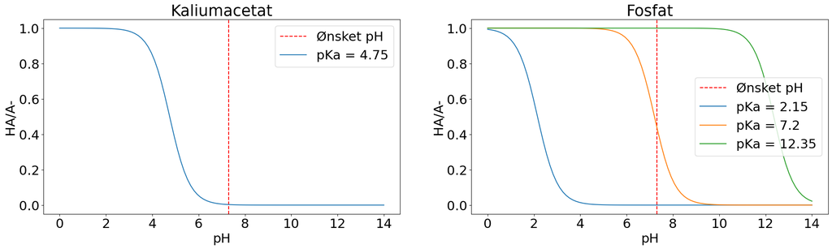

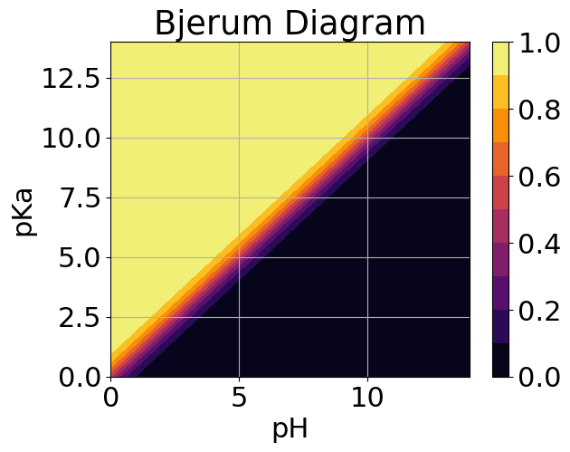

```python
kal_ace_pka = 4.75
phos_pka = np.array([2.15, 7.20, 12.35])

fig = plt.figure(figsize=(24, 6))
ax_kal_ace = fig.add_subplot(121)
ax_kal_ace.set_title("Kaliumacetat")
ax_kal_ace.axvline(7.3, color="r", linestyle="--", label="Ønsket pH")

ax_phos = fig.add_subplot(122)
ax_phos.axvline(7.3, color="r", linestyle="--", label="Ønsket pH")
ax_phos.set_title("Fosfat")

ratio_kal = plot_bjerum_diagram(kal_ace_pka, ax=ax_kal_ace)
ratio_phos = plot_bjerum_diagram(phos_pka, ax=ax_phos)

spicific_ratio_kal = bjerum_diagram(7.3, kal_ace_pka)
spicific_ratio_pho = bjerum_diagram(7.3, phos_pka)


text = f"""
### Kaliumacetat
- pKa = {kal_ace_pka}
- Ønsket pH = 7.3
- Ønsket ratio = {spicific_ratio_kal:.2f}

### Fosfat
- pKa = {phos_pka}
- Ønsket pH = 7.3
- Ønsket ratio = {np.round(spicific_ratio_pho, 2)}

___
"""

_ = plot_2D_bjerum_diagram(100, 0, 14)
md(text)
```

#### c)

Forslå en opskrift på bufferen

Ratio mellem mono- og biphosphat:  
$pH = pKA + log\frac{A-}{HA}$  
$7,3 = 7,21 + log\frac{A-}{HA}$  
$\frac{A-}{HA} = 10^{7,3-7,21} = 1,23$

Det giver mening, vi er over pKA  
Der er mindst HA, så [HA] = 1 M, hvilket betyder at [A-] = 1,23 M og c(H3PO4) = 2,23 M

Fosforsyre: $2,23 mol * 97,994 g/mol = 218,52 g \: for\:100\%$ dvs. $273,2 g\:for\:80\%$

***Da vi er på en pH på 7.3, vil vi have en ratio mellem mono- og bisphosphat givet a pKa på 7.21.***

$H_2PO_4^- + H_2O \rightleftharpoons HPO_4^{2-} + H_3O^+$

***Da vi har den trivalente fosforsyre, vil vi skulle bruge 2,23 mol NaOH for at fuld reageare alt vores $H_3PO_4$ til $H_2PO_4^-$ før at vi kan lave vores korekte ratio i bufferen defor først 2.23M og derefter 1.23M for den øsnkede balance***

NaOH: (2,23+1,23 mol)* 39,997 g/mol =138,390 g  
___

### Opgave 3: Termodynamik og kinetik - 30 point

I har disse tre ligevægte, der alle involverer ilt:  
HO·(g) + HO·(g) = H2O(g) + O·(g)  
HO·(g) + H2(g) = H2O(g) + H·(g)  
HO·(g) + HO·(g) = H2O2(g)

***$O\cdot$ skulle havde været listet i tabellen. Hvis lignende skulle ske i fremtiden, kan dette bliver fundet her: https://webbook.nist.gov/chemistry/ hvorfra man kan søge [Search -> Formula -> X phase thermochemistry data] X givet tilstanden***

#### a)

Udregn ΔH og ΔS for hver reaktion ud fra tabelværdierne.

```python
h_ho = 38.99
h_h2o = -241.8
h_h2 = 0
h_h = 218.0
h_h2o2 = -136.11
h_o2 = 0
h_o = 249.17  # Fundet på nettet

s_ho = 183.71
s_h2o = 188.7
s_h2o2 = 232.95
s_h2 = 131
s_h = 114.72
s_o2 = 205
s_o = 161.05  # Fundet på nettet

hr_1 = (h_h2o + h_o) - (h_ho * 2)
sr_1 = (s_h2o + s_o) - (s_ho * 2)

hr_2 = (h_h2o + h_h) - (h_ho + h_h2)
sr_2 = (s_h2o + s_h) - (s_ho + s_h2)

hr_3 = (h_h2o2) - (h_ho * 2)
sr_3 = (s_h2o2) - (s_ho * 2)

text = f"""
$\Delta H_{{Reaktion}} 1 = {hr_1:.2f} kJ/mol$\\
$\Delta S_{{Reaktion}} 1 = {sr_1:.2f} J/mol \cdot K$

$\Delta H_{{Reaktion}} 2 = {hr_2:.2f} kJ/mol$\\
$\Delta S_{{Reaktion}} 2 = {sr_2:.2f} J/mol \cdot K$

$\Delta H_{{Reaktion}} 3 = {hr_3:.2f} kJ/mol$\\
$\Delta S_{{Reaktion}} 3 = {sr_3:.2f} J/mol \cdot K$
___
"""


md(text)
```

$\Delta H_{Reaktion} 1 = -70.61 kJ/mol$  
$\Delta S_{Reaktion} 1 = -17.67 J/mol \cdot K$

$\Delta H_{Reaktion} 2 = -62.79 kJ/mol$  
$\Delta S_{Reaktion} 2 = -11.29 J/mol \cdot K$

$\Delta H_{Reaktion} 3 = -214.09 kJ/mol$  
$\Delta S_{Reaktion} 3 = -134.47 J/mol \cdot K$ ___

#### b)

Opskriv funktionen for ΔG(T) for hver reaktion

```python
def delta_g_func_wrapper(hr, sr):
    return lambda t: hr - t * sr / 1000


func_1 = delta_g_func_wrapper(hr_1, sr_1)
func_2 = delta_g_func_wrapper(hr_2, sr_2)
func_3 = delta_g_func_wrapper(hr_3, sr_3)
```

#### c\d)

Plot ΔG(T) for hver reaktion fra T = 0K til T = 400K. Der må bruges én graf i besvarelsen.

[output not shown]

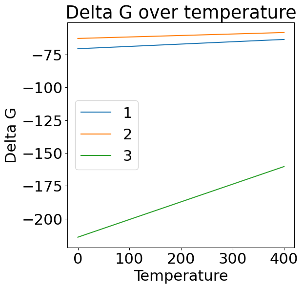

```python
t = np.linspace(0, 400, 1000)

line_1 = func_1(t)
line_2 = func_2(t)
line_3 = func_3(t)

fig, ax = plt.subplots(figsize=(6, 6))
ax.plot(t, line_1, label="1")
ax.plot(t, line_2, label="2")
ax.plot(t, line_3, label="3")
ax.legend()
ax.set(xlabel="Temperature", ylabel="Delta G", title="Delta G over temperature")
```

#### d/c)

Angiv ved hvilken temperatur, hvor der ingen drivkraft er for reaktionen

```python
T_01 = hr_1 / (sr_1 / 1000)
T_02 = hr_2 / (sr_2 / 1000)
T_03 = hr_3 / (sr_3 / 1000)

text = f"""
$T_{{01}} = {T_01:.2f} K$\\
$T_{{02}} = {T_02:.2f} K$\\
$T_{{03}} = {T_03:.2f} K$


___
"""

md(text)
```

$T_{01} = 3996.04 K$  
$T_{02} = 5561.56 K$  
$T_{03} = 1592.10 K$

#### e)

Argumenter for hvilken reaktion, du forventer at der vil ske når to hydroxyl-radikaler mødes i atmosfæren|

Baseret på termodynamik alene, så danner hydroxylradikaler hydrogenperoxid. ___

### Opgave 4: Elektrokemi – 22 point

Bombaderbillen har en kirtel med to kamre, der hver indeholder reaktive kemikalier opløst i vand. Når disse blandes udvikles der varme, og billen kan derfor udsende en varm sky af damp (og kemikalier), som kan skramme angribere væk.

#### a)

I det ene kammer har billen hydroquinon, der kan oxideres til quinon med Ered =+0,699 V. Slå disse kemikalier op og opskriv halvcellereaktionen.

$C_6H_4O_2 + 2H^+ + 2e^- = C_6H_4(OH)_2$

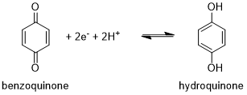

___

#### b)

I det andet kammer har billen hydrogenperoxid, der reduceres til vand, opskriv denne halvreaktion.

$H_2O_2 + 2H^+ + 2e^- = 2H_2O$ ___

#### c)

Opskriv totalreaktionen og udregn ΔG og K for ligevægten.

$C_6H_4(OH)_2 + H_2O_2 = C_6H_4O_2 + 2H_2O$

$E^0_{cell} = E^0_{red / cathode} - E^0_{red / anode}$

$\Delta G = -nFE^0_{cell}$

Anode: Hvor elektroner afgives eller tages fra

Catode: Hvor elektroner tages op eller gives til

```python
E_cathode = 1.776  # V
E_anode = 0.699  # V
Faraday = 96485  # C/mol
E_cell = E_cathode - E_anode
gr = -2 * Faraday * E_cell / 1000
k = np.exp(-gr * 1000 / (R * c_2_k(25)))

text = f"""
$E_{{cell}} = {E_cell:.3f} V$\\
$\Delta G = {gr:.3f} kJ/mol$\\
$K = {k:.3e}$
___
"""

md(text)
```

$E_{cell} = 1.077 V$  
$\Delta G = -207.829 kJ/mol$  
$K = 2.582e+36$ ___

#### d)

Argumenter for hvilke værdier du skal bruge for at kunne beskrive, hvor varm væsken som billen skyder ud bliver

Hvis vi skal kunne regne temperaturen ud, skal vi kende varmeudviklingen = ΔH [kJ/mol]. Vi skal kende varmekapaciteten cP [J/gK] af væsken, stofmængden af reagenser [mol] og massen af væske [g] for at regne ud hvor varmt det bliver. ___

#### e)

Skitser det galvaniske element der er beskrevet ved:  
Pt(s)| C6H4O2 (aq, 0,022 M), C6H6O2 (aq, 0,008 M) HBr (aq, 0,01 M)|| H2O2 (aq, 0,20 M)| HBr (aq, 0,01 M)|Pt(s)

***Der var ved en fejl en ekstra fasegrænse (|) ved højre celle $HBr$ i opgaven***

***Anode (oxidation)***: er på den venstre side* **Cathode (Reduction)***: er på den højre side* **En enkelt linje (|)*** angiver en fasegrænse  
***en dobbelt linje (||)*** angiver en saltbro eller en anden form for forbindelse mellem de to halvceller.

Her er det givet at:

***Venstre side (Anode)***:

Pt(s)∣C₆H₄O₂(aq, 0,022 M), C₆H₆O₂(aq, 0,008 M), HBr(aq, 0,01 M)  
Pt(s): Inert elektrode til elektronoverførsel.  
C₆H₆O₂ (0,008 M): Hydroquinon (reduktionsmiddel).  
C₆H₄O₂ (0,022 M): Quinon (oxideret form).  
HBr (0,01 M): Leverer H⁺-ioner for at opretholde ladningsbalance.

***Højre side (Katode)***:

H₂O₂(aq, 0,20 M), HBr(aq, 0,01 M)∣Pt(s)  
H₂O₂ (0,20 M): Brintoverilte (oxidationsmiddel).  
HBr (0,01 M): Leverer H⁺-ioner til reduktionsreaktionen.  
Pt(s): Inert elektrode til elektronoverførsel.

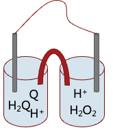

#### f)

Beregn den elektromotoriske kraft og Gibbs energien for cellen.

$E = E^0_{cell} - \frac{RT}{nF}lnQ$

$Q = \frac{[H_2O][Q]}{[H_2O_2][H_2Q]}$

```python
Q = (0.022) / (0.20 * 0.008)
R = 8.3145

rt_nf_const = (R * c_2_k(25)) / (2 * Faraday)  # 2 elektroner overføres
E = E_cell - (rt_nf_const * np.log(Q))
gr = -2 * Faraday * E / 1000

text = f"""
$Q = {Q:.3f}$\\
$E = {E:.3f} V$\\
$\Delta G = {gr:.3f}$ kJ/mol
___
"""

md(text)
```

$Q = 13.750$  
$E = 1.043 V$  
$\Delta G = -201.331$ kJ/mol ___

#### g)

Beregn koncentrationerne af stofferne i opløsning ved ligevægt.

Opsætning a sildeben tabel, og beregn koncentrationerne af stofferne ved ligevægt.

| Stof | Start | Forbrug | Ligevægt |
| --- | --- | --- | --- |
| C6H4O2 | 0,022 M | +x | 0,022+x |
| C6H6O2 | 0,008 M | -x | 0,008-x |
| H2O2 | 0,20 M | -x | 0,20-x |

$K = \frac{[C_6H_4O_2]}{[C_6H_6O_2][H_2O_2]} = \frac{0.022 + x}{(0.008 - x)(0.20 -x)}$

Dat ligevægten er så stor må alt reagenset være forbrugt og x bestemmes derfra af den begrensende faktor (x = 0.008)  
$[C_6H_4O_2] = 0.03 M$  
$[C_6H_6O_2] = 0 M$  
$[H_2O_2] = 0.192 M$